# Hyperparameters and Model Tuning

## Recap

In our most recent notebooks, we’ve gone beyond *Ordinary Least Squares* and explored additional classes of model. We began with *penalized* least squares models like Ridge Regression and the LASSO. We extended our knowledge of model classes to *nearest neighbor* and *tree-based models* as well as *ensembles* of models in the previous notebook. We ended that notebook with a short discussion on parameter choices that must be made prior to model training – such parameters are known as *hyperparameters*. In this notebook, we learn how to use *cross-validation* to *tune* our model *hyperparameters*.

## Objectives

In this notebook, we’ll accomplish the following:

- Use `tune()` for model parameters as well as in feature engineering steps to identify hyperparameters that we want to tune through cross-validation.
- Use cross-validation and `tune_grid()` to tune the hyperparameters for a single model, identify the best hyperparameter choices, and fit the model using those best choices.
- Build a `workflow_set()`, choose hyperparameters that must be tuned for each model and recipe, use *cross-validation* to tune models and select “optimal” hyperparameter values, and compare the models in the workflow set.

## Tuning Hyperparameters for a Single Model

Let’s start with a decision tree model and we’ll tune the tree depth parameter. We’ll work with the `ames` data again for now.

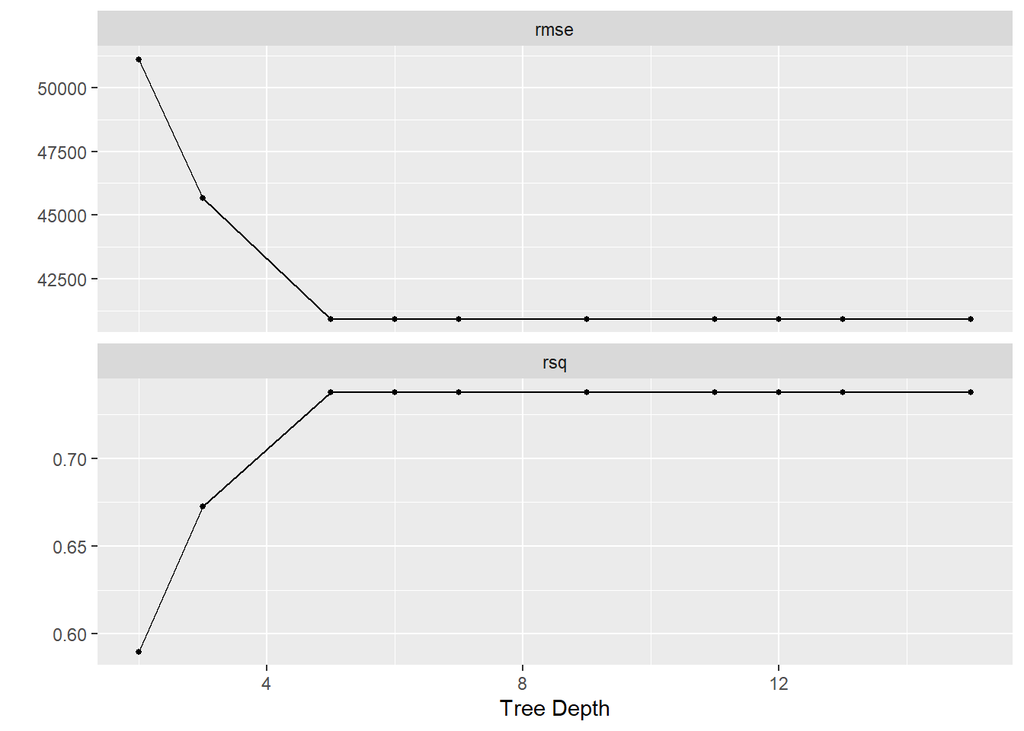

```r
ames_known_prices <- ames %>%
  filter(!is.na(Sale_Price))

ames_split <- initial_split(ames_known_prices, prop = 0.9)
ames_train <- training(ames_split)
ames_test <- testing(ames_split)

ames_folds <- vfold_cv(ames_train, v = 5)

tree_spec <- decision_tree(tree_depth = tune()) %>%
  set_engine("rpart") %>%
  set_mode("regression")

tree_rec <- recipe(Sale_Price ~ ., data = ames_train) %>%
  step_other(all_nominal_predictors()) %>%
  step_unknown(all_nominal_predictors()) %>%
  step_impute_median(all_numeric_predictors())

tree_wf <- workflow() %>%
  add_model(tree_spec) %>%
  add_recipe(tree_rec)

set.seed(123)
tree_results <- tree_wf %>%
  tune_grid(ames_folds, grid =12)

tree_results %>%
  autoplot()
```

We see from the plots above that deeper trees seemed to perform better than shallow trees. We don’t observe much improvement in performance after a depth of 5. The risk of overfitting increases with deeper trees. We do seem to get some benefit by increasing the depth of the tree beyond 4. For this reason, I’ll choose a tree depth of 5. The output of `show_best()` below shows our best-performing depths in terms of RMSE.

```r
tree_results %>%
  show_best(n = 10)
```

```
## # A tibble: 10 × 7
##    tree_depth .metric .estimator   mean     n std_err .config
##         <int> <chr>   <chr>       <dbl> <int>   <dbl> <chr>
##  1         12 rmse    standard   40918.     5   1144. Preprocessor1_Model01
##  2          7 rmse    standard   40918.     5   1144. Preprocessor1_Model02
##  3          9 rmse    standard   40918.     5   1144. Preprocessor1_Model03
##  4         11 rmse    standard   40918.     5   1144. Preprocessor1_Model05
##  5          6 rmse    standard   40918.     5   1144. Preprocessor1_Model06
##  6         15 rmse    standard   40918.     5   1144. Preprocessor1_Model07
##  7          5 rmse    standard   40918.     5   1144. Preprocessor1_Model08
##  8         13 rmse    standard   40918.     5   1144. Preprocessor1_Model10
##  9          3 rmse    standard   45682.     5   1073. Preprocessor1_Model04
## 10          2 rmse    standard   51103.     5    456. Preprocessor1_Model09
```

We can now build a final fit using this depth.

```r
best_params <- tibble(tree_depth = 5)

tree_wf_final <- tree_wf %>%
  finalize_workflow(best_params)

tree_fit <- tree_wf_final %>%
  fit(ames_train)

tree_fit
```

```
## ══ Workflow [trained] ══════════════════════════════════════════════════════════
## Preprocessor: Recipe
## Model: decision_tree()
##
## ── Preprocessor ────────────────────────────────────────────────────────────────
## 3 Recipe Steps
##
## • step_other()
## • step_unknown()
## • step_impute_median()
##
## ── Model ───────────────────────────────────────────────────────────────────────
## n= 2637
##
## node), split, n, deviance, yval
##       * denotes terminal node
##
##  1) root 2637 1.665176e+13 180777.1
##    2) Garage_Cars< 2.5 2281 6.571010e+12 161252.4
##      4) Overall_Qual=Above_Average,Average,Below_Average,other 1645 2.905494e+12 142024.3
##        8) Gr_Liv_Area< 1379 1013 9.109336e+11 125850.2
##         16) Total_Bsmt_SF< 969.5 623 4.437551e+11 113570.5 *
##         17) Total_Bsmt_SF>=969.5 390 2.231683e+11 145466.2 *
##        9) Gr_Liv_Area>=1379 632 1.304795e+12 167949.0
##         18) Kitchen_Qual=Typical,other 442 5.031614e+11 154717.3 *
##         19) Kitchen_Qual=Excellent,Good 190 5.442265e+11 198730.2
##           38) Overall_Qual=Above_Average,Average,Below_Average 169 2.975804e+11 186984.1 *
##           39) Overall_Qual=other 21 3.568281e+10 293258.2 *
##      5) Overall_Qual=Good,Very_Good 636 1.484267e+12 210985.3
##       10) First_Flr_SF< 1493 497 7.817379e+11 198491.6
##         20) Gr_Liv_Area< 1753.5 333 3.351778e+11 184776.1 *
##         21) Gr_Liv_Area>=1753.5 164 2.567234e+11 226340.8 *
##       11) First_Flr_SF>=1493 139 3.475670e+11 255657.1 *
##    3) Garage_Cars>=2.5 356 3.639695e+12 305878.3
##      6) Bsmt_Qual=Good,Typical,other 199 9.751464e+11 252555.8
##       12) Year_Remod_Add< 1977.5 30 4.312190e+10 146830.0 *
##       13) Year_Remod_Add>=1977.5 169 5.371586e+11 271323.7
##         26) Mas_Vnr_Area< 364 131 1.980484e+11 252809.1 *
##         27) Mas_Vnr_Area>=364 38 1.393992e+11 335150.3 *
##      7) Bsmt_Qual=Excellent 157 1.381557e+12 373465.3
##       14) Overall_Qual=Good,Very_Good 66 1.987342e+11 314666.5 *
##       15) Overall_Qual=other 91 7.891466e+11 416110.6
##         30) Gr_Liv_Area< 2336 57 1.392907e+11 372776.6 *
##         31) Gr_Liv_Area>=2336 34 3.633754e+11 488758.8 *
```

We can see the tree as well, using `rpart.plot()`.

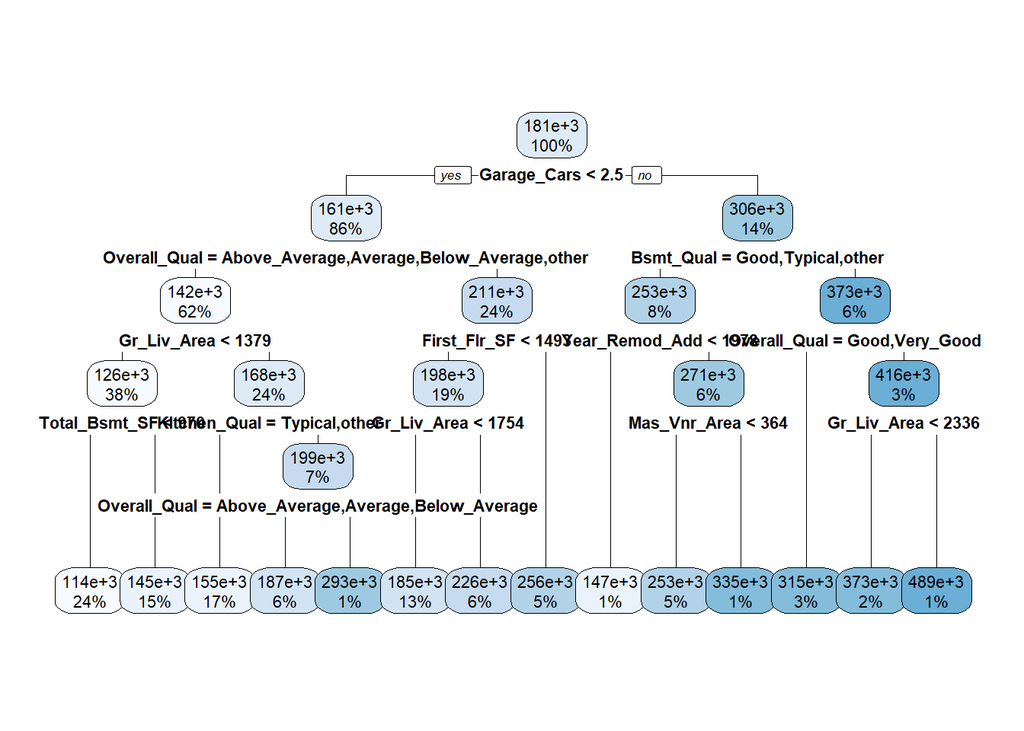

```r
library(rpart.plot)
tree_fit_for_plot <- tree_fit %>%
  extract_fit_engine()

rpart.plot(tree_fit_for_plot, tweak = 1.5)
```

The model we built above can be interpreted and can also be utilized to make predictions on new data just like out previous models. Next, let’s look at how we can tune multiple models with a variety of hyperparameters in a `workflow_set()`. We’ll fit a *LASSO*, a *random forest*, and a *gradient boosted* model.

## Tuning Hyperparameters Across a Workflow Set

Let’s create model specifications and recipes for each of the models mentioned previously.

```r
doParallel::registerDoParallel()

lasso_spec <- linear_reg(penalty = tune(), mixture = 1) %>%
  set_engine("glmnet")

rf_spec <- rand_forest(mtry = tune(), trees = 100) %>%
  set_engine("ranger") %>%
  set_mode("regression")

gb_spec <- boost_tree(mtry = tune(), trees = 100, learn_rate = tune()) %>%
  set_engine("xgboost") %>%
  set_mode("regression")

rec <- recipe(Sale_Price ~ ., data = ames_train) %>%
  step_impute_knn(all_predictors()) %>%
  step_other(all_nominal_predictors(), threshold = 0.10) %>%
  step_dummy(all_nominal_predictors())

rec_list = list(rec = rec)
model_list = list(lasso = lasso_spec, rf = rf_spec, gb_tree = gb_spec)

model_wfs <- workflow_set(rec_list, model_list, cross = TRUE)

grid_ctrl <- control_grid(
  save_pred = TRUE,
  parallel_over = "everything",
  save_workflow = TRUE
)

grid_results <- model_wfs %>%
  workflow_map(
    seed = 123,
    resamples = ames_folds,
    grid = 5,
    control = grid_ctrl)
```

```
## i Creating pre-processing data to finalize unknown parameter: mtry
## i Creating pre-processing data to finalize unknown parameter: mtry
```

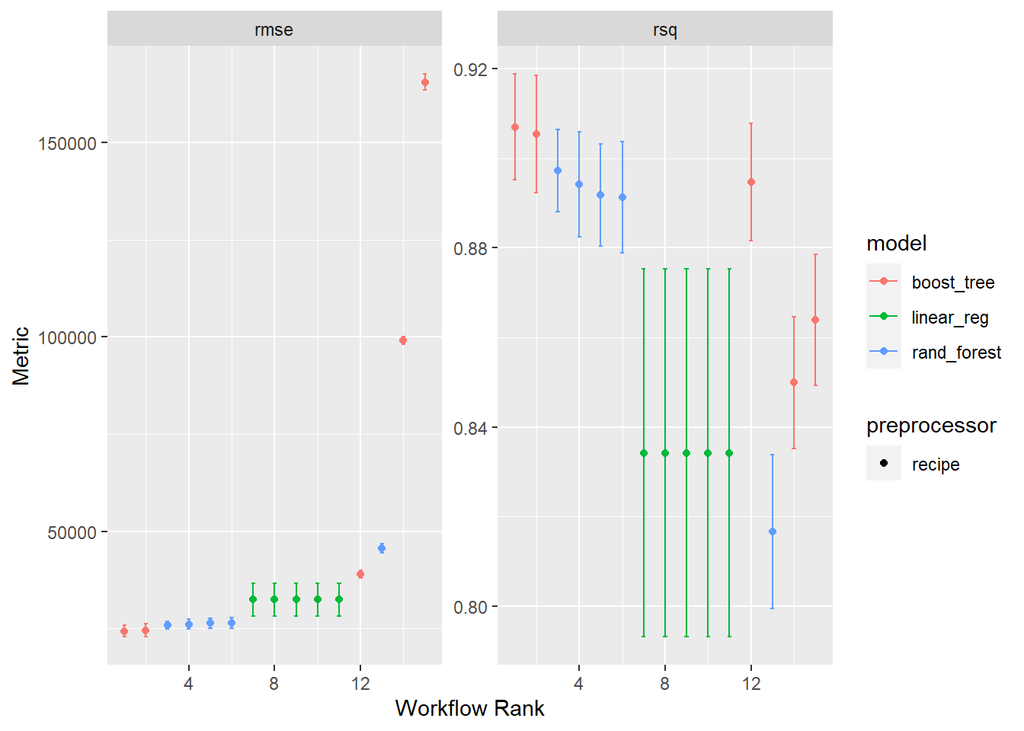

```r
grid_results %>%
  autoplot()
```

Now let’s see what the best models were!

```r
grid_results %>%
  rank_results()
```

```
## # A tibble: 30 × 9
##    wflow_id    .config         .metric    mean std_err     n prepr…¹ model  rank
##    <chr>       <chr>           <chr>     <dbl>   <dbl> <int> <chr>   <chr> <int>
##  1 rec_gb_tree Preprocessor1_… rmse    2.43e+4 9.22e+2     5 recipe  boos…     1
##  2 rec_gb_tree Preprocessor1_… rsq     9.07e-1 7.15e-3     5 recipe  boos…     1
##  3 rec_gb_tree Preprocessor1_… rmse    2.45e+4 9.99e+2     5 recipe  boos…     2
##  4 rec_gb_tree Preprocessor1_… rsq     9.05e-1 7.98e-3     5 recipe  boos…     2
##  5 rec_rf      Preprocessor1_… rmse    2.58e+4 5.70e+2     5 recipe  rand…     3
##  6 rec_rf      Preprocessor1_… rsq     8.97e-1 5.60e-3     5 recipe  rand…     3
##  7 rec_rf      Preprocessor1_… rmse    2.61e+4 7.54e+2     5 recipe  rand…     4
##  8 rec_rf      Preprocessor1_… rsq     8.94e-1 7.14e-3     5 recipe  rand…     4
##  9 rec_rf      Preprocessor1_… rmse    2.64e+4 7.72e+2     5 recipe  rand…     5
## 10 rec_rf      Preprocessor1_… rsq     8.92e-1 6.93e-3     5 recipe  rand…     5
## # … with 20 more rows, and abbreviated variable name ¹preprocessor
```

The model performing the best was the *gradient boosted tree ensemble*. Let’s see what hyperparameter choices led to the best performance.

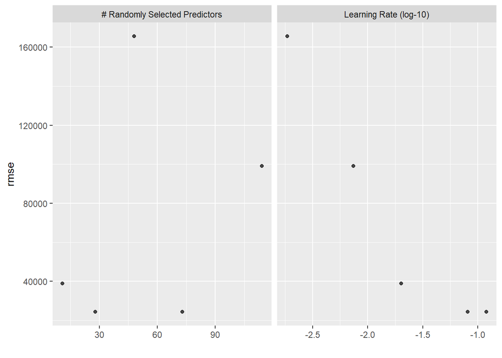

```r
grid_results %>%
  autoplot(metric = "rmse", id = "rec_gb_tree")
```

It seems that a number of randomly selected parameters of near 30 gave the best performance and learning rates near 0.1 did as well. We’ll construct this model and fit it to our training data.

```r
set.seed(123)
gb_tree_spec <- boost_tree(mtry = 30, trees = 100, learn_rate = 0.1) %>%
  set_engine("xgboost") %>%
  set_mode("regression")

gb_tree_wf <- workflow() %>%
  add_model(gb_tree_spec) %>%
  add_recipe(rec)

gb_tree_fit <- gb_tree_wf %>%
  fit(ames_train)
```

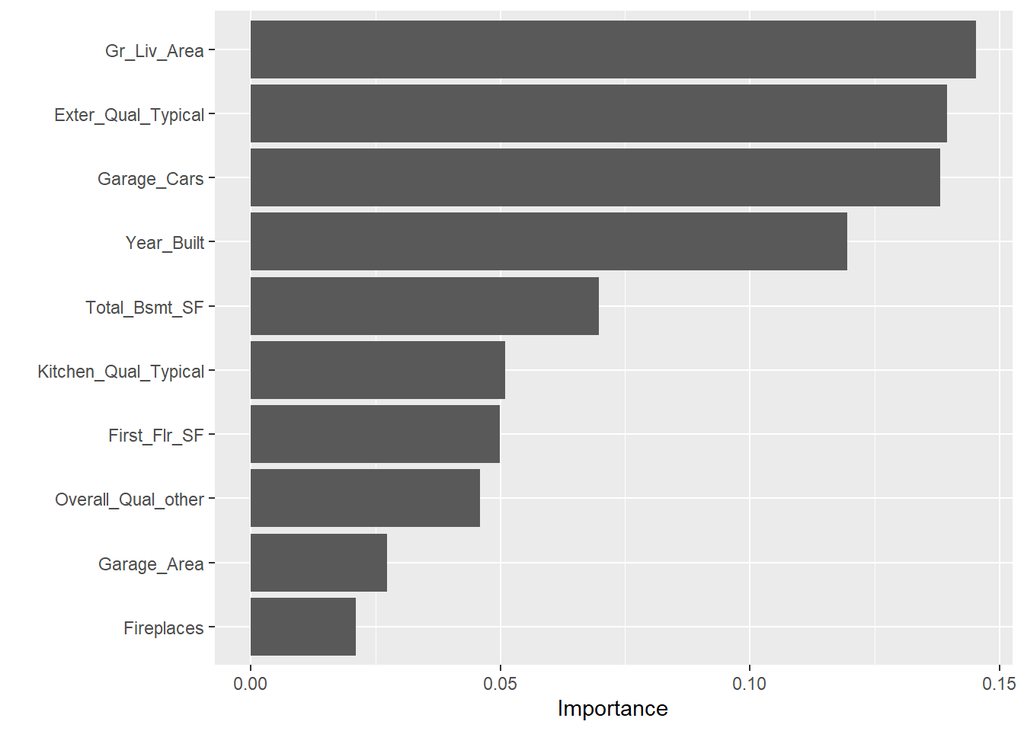

```r
library(vip)
gb_tree_fit %>%
  extract_fit_engine() %>%
  vip()
```

From the plot above, we can see the features that were most the important predictors of *selling price* within the ensemble. Note that the important predictors will shuffle around slightly each time you re-run the ensemble. Before we close this notebook, let’s take a look at how well this model predicts the selling prices of homes in our *test* set.

```r
gb_results <- gb_tree_fit %>%
  augment(ames_test) %>%
  select(Sale_Price, .pred) %>%
  rmse(Sale_Price, .pred)

gb_results %>%
  kable() %>%
  kable_styling(bootstrap_options = c("striped", "hover"))
```

| .metric | .estimator | .estimate |
| --- | --- | --- |
| rmse | standard | 28326.53 |

This final ensemble of models predicted selling prices of homes with an root mean squared error of $ 28,326.53.

## Summary

In this notebook, we saw how to build a workflow set consisting of several models with tunable hyperparameters. We explored a *space-filling grid* of hyperparameter combinations with a `workflow_map()`. After identifying a best model and optimal(*) hyperparameter choices, we fit the corresponding model to our training data and then assessed that model’s performance on our test data.